# CS422 Section 01

### 2.1(c)

```r
library(e1071)
model.predict <- predict(model.train, adult.test.dataset, type="class")
#model.predict
confusion.matrix<-confusionMatrix(model.predict, adult.test.dataset[, 15])
confusion.matrix
```

```
## Confusion Matrix and Statistics
##
##           Reference
## Prediction <=50K  >50K
##      <=50K 10772  1837
##      >50K    588  1863
##
##                Accuracy : 0.839
##                  95% CI : (0.833, 0.8448)
##     No Information Rate : 0.7543
##     P-Value [Acc > NIR] : < 2.2e-16
##
##                   Kappa : 0.5098
##  Mcnemar's Test P-Value : < 2.2e-16
##
##             Sensitivity : 0.9482
##             Specificity : 0.5035
##          Pos Pred Value : 0.8543
##          Neg Pred Value : 0.7601
##              Prevalence : 0.7543
##          Detection Rate : 0.7153
##    Detection Prevalence : 0.8373
##       Balanced Accuracy : 0.7259
##
##        'Positive' Class : <=50K
##
```

#### 2.1(c) (i)

```r
sensitivity<- as.numeric(formatC(confusion.matrix$byClass[1], digits = 3, format = "f"))
specificity<- as.numeric(formatC(confusion.matrix$byClass[2], digits = 3, format = "f"))
balanced.accuracy.model <-(sensitivity+specificity)/2
balanced.accuracy.model <- round(balanced.accuracy.model,digits=3)
cat("The Balance Accuracy(average of sensitivity and specificity) of the model is:",balanced.accuracy.model,"\n")
```

```
## The Balance Accuracy(average of sensitivity and specificity) of the model is: 0.726
```

#### 2.1(c) (ii)

```r
balanced.error.rate <- 1.0 - balanced.accuracy.model
cat("The Balanced error rate of the model:",balanced.error.rate,"\n")
```

```
## The Balanced error rate of the model: 0.274
```

#### 2.1(c) (iii)

```r
cat("The Sensitivity is: ",sensitivity,"\n")
```

```
## The Sensitivity is:  0.948
```

```r
cat("The specificity is: ",specificity,"\n")
```

```
## The specificity is:  0.504
```

#### 2.1(c) (iv)

```r
library(ROCR)
```

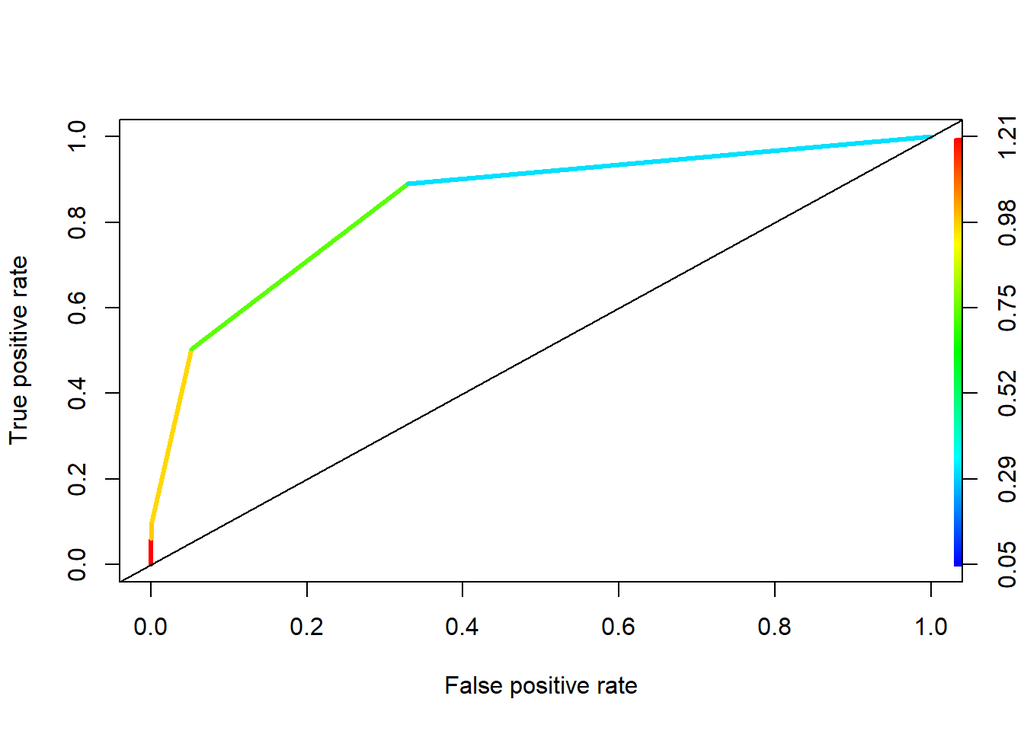

```r
rocr.predict <- predict(model.train, newdata=adult.test.dataset, type="prob")[,2]
income.pred <- prediction(rocr.predict, adult.test.dataset$income)
income.perf <- performance(income.pred, "tpr", "fpr")
plot(income.perf, colorize=T, lwd=3)
abline(0,1)
```

```r
auc <- performance(income.pred, measure = "auc")
cat("The area under curve (AUC) for this model:", round(auc@y.values[[1]], 3))
```

```
## The area under curve (AUC) for this model: 0.843
```

### 2.1(d)

```r
library(rpart)
options("digits"=5)
printcp(model.train)
```

```
##
## Classification tree:
## rpart(formula = income ~ ., data = adult.train.dataset, method = "class")
##
## Variables actually used in tree construction:
## [1] capital_gain education    relationship
##
## Root node error: 7508/30161 = 0.249
##
## n= 30161
##
##       CP nsplit rel error xerror    xstd
## 1 0.1300      0     1.000  1.000 0.01000
## 2 0.0642      2     0.740  0.740 0.00897
## 3 0.0373      3     0.676  0.676 0.00865
## 4 0.0100      4     0.639  0.639 0.00846
```

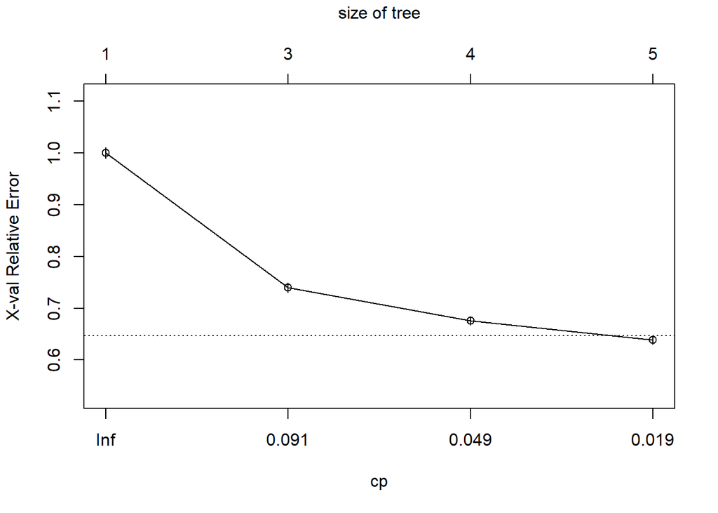

```r
plotcp(model.train)
```

The tree wouldn’t benefit from pruning as the percentage of xerror (cross validation error) keeps reducing at each level and there is no level in which the xerror percentage increases when compared to the previous level. Pruning the tree would result in increase of xerror percentage. This shows that the decision tree model does not need pruning and the model works fine for the test data(indications of absence of overfitting on the train data).The xerror is the lowest at the 4th split or the last split. The complexity level at which pruning should be done can be calculated using the below code:

```r
complexity.level=model.train$cptable[which.min(model.train$cptable[,"xerror"]), "CP"]
cat("Complexity level where the tree should be pruned: ", complexity.level , "\n")
```

```
## Complexity level where the tree should be pruned:  0.01
```

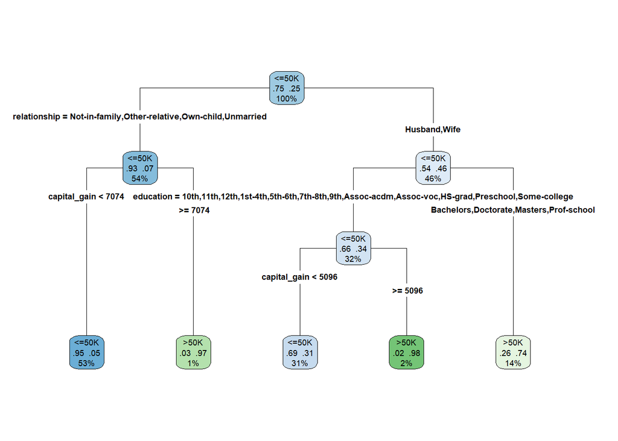

```r
prune.tree <- prune(model.train, cp=complexity.level)
rpart.plot(prune.tree, extra=104, fallen.leaves = T, type=4)
```

```r
predict.prune.tree <- predict(prune.tree, adult.test.dataset, type="class")
confusionMatrix(predict.prune.tree, adult.test.dataset[, 15])
```

```
## Confusion Matrix and Statistics
##
##           Reference
## Prediction <=50K  >50K
##      <=50K 10772  1837
##      >50K    588  1863
##
##                Accuracy : 0.839
##                  95% CI : (0.833, 0.845)
##     No Information Rate : 0.754
##     P-Value [Acc > NIR] : <2e-16
##
##                   Kappa : 0.51
##  Mcnemar's Test P-Value : <2e-16
##
##             Sensitivity : 0.948
##             Specificity : 0.504
##          Pos Pred Value : 0.854
##          Neg Pred Value : 0.760
##              Prevalence : 0.754
##          Detection Rate : 0.715
##    Detection Prevalence : 0.837
##       Balanced Accuracy : 0.726
##
##        'Positive' Class : <=50K
##
```

```r
#From the confusion matrix, it is clearly visible that pruning does not help as all the values of metrics are same compared to the values of metrics before pruning.
```

### 2.1(e)

#### 2.1(e) (i)

```r
less.50k<-which(adult.train.dataset$income=="<=50K")
grear.50k<-which(adult.train.dataset$income==">50K")
cat("Observations in training dataset with <=50K",NROW(less.50k),"\n")
```

```
## Observations in training dataset with <=50K 22653
```

```r
cat("Observations in training dataset with >50K",NROW(grear.50k),"\n")
```

```
## Observations in training dataset with >50K 7508
```

#### 2.1(e) (ii)

```r
index.remove <- sample(which(adult.train.dataset$income=="<=50K"), size=15145)
new.adult.train.dataset <- adult.train.dataset[-index.remove,]

table(new.adult.train.dataset$income)
```

```
##
## <=50K  >50K
##  7508  7508
```

#### 2.1(e) (iii)

```r
new.model.train <- rpart(income ~ ., method="class", data=new.adult.train.dataset)
summary(new.model.train)
```

```
## Call:
## rpart(formula = income ~ ., data = new.adult.train.dataset, method = "class")
##   n= 15016
##
##         CP nsplit rel error  xerror      xstd
## 1 0.520112      0   1.00000 1.02531 0.0081580
## 2 0.039425      1   0.47989 0.48095 0.0069753
## 3 0.015117      2   0.44046 0.44126 0.0067680
## 4 0.010000      6   0.37999 0.39798 0.0065161
##
## Variable importance
## marital_status   relationship     occupation            sex            age
##             28             28             10             10              8
##   capital_gain hours_per_week      education  education_num
##              7              4              3              3
##
## Node number 1: 15016 observations,    complexity param=0.52011
##   predicted class=<=50K  expected loss=0.5  P(node) =1
##     class counts:  7508  7508
##    probabilities: 0.500 0.500
##   left son=2 (6103 obs) right son=3 (8913 obs)
##   Primary splits:
##       marital_status splits as  LRRLLLL, improve=2104.70, (0 missing)
##       relationship   splits as  RLLLLR, improve=2104.00, (0 missing)
##       age            < 28.5   to the left,  improve=1017.90, (0 missing)
##       occupation     splits as  -LLLRLLLLLRRRRL, improve= 916.97, (0 missing)
##       education      splits as  LLLLLLLLLRRLRLRL, improve= 891.61, (0 missing)
##   Surrogate splits:
##       relationship   splits as  RLLLLR, agree=0.995, adj=0.987, (0 split)
##       sex            splits as  LR, agree=0.732, adj=0.340, (0 split)
##       age            < 29.5   to the left,  agree=0.697, adj=0.255, (0 split)
##       occupation     splits as  -LLRRRLRLLRRRRR, agree=0.663, adj=0.171, (0 split)
##       hours_per_week < 39.5   to the left,  agree=0.645, adj=0.126, (0 split)
##
## Node number 2: 6103 observations,    complexity param=0.039425
##   predicted class=<=50K  expected loss=0.18008  P(node) =0.40643
##     class counts:  5004  1099
##    probabilities: 0.820 0.180
##   left son=4 (5763 obs) right son=5 (340 obs)
##   Primary splits:
```

[output cut: 92 more lines]

```
##       native_country splits as  -RRRLRLRRR-RRRR--RLRLRLR-LR--RRRR-RRRRRRL, agree=0.689, adj=0.022, (0 split)
##       relationship   splits as  RLRL-R, agree=0.685, adj=0.009, (0 split)
##       race           splits as  RRRLR, agree=0.684, adj=0.006, (0 split)
##       marital_status splits as  -LR----, agree=0.683, adj=0.003, (0 split)
##       capital_gain   < 4447   to the right, agree=0.682, adj=0.001, (0 split)
##
## Node number 50: 777 observations
##   predicted class=<=50K  expected loss=0.37452  P(node) =0.051745
##     class counts:   486   291
##    probabilities: 0.625 0.375
##
## Node number 51: 1666 observations
##   predicted class=>50K   expected loss=0.40876  P(node) =0.11095
##     class counts:   681   985
##    probabilities: 0.409 0.591
```

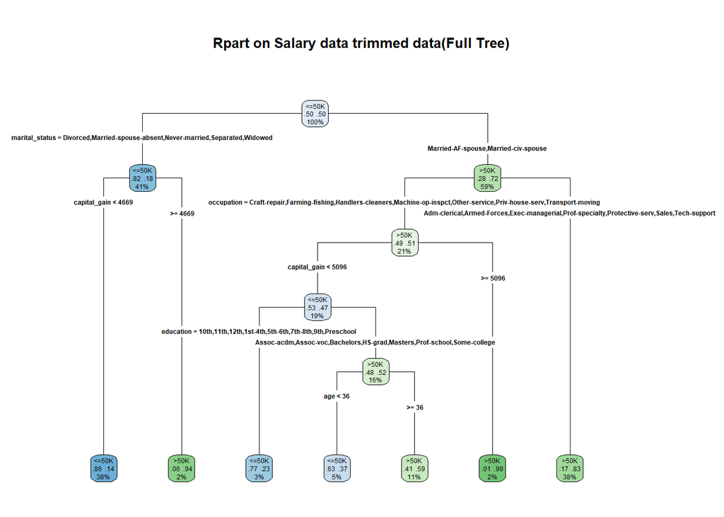

```r
rpart.plot(new.model.train, extra=104, fallen.leaves = T, type=4, main="Rpart on Salary data trimmed data(Full Tree)")
```

```r
predict.test.balanced<- predict(new.model.train, adult.test.dataset, type="class")
confusionMatrix(predict.test.balanced,as.factor(adult.test.dataset[, 15]))
```

```
## Confusion Matrix and Statistics
##
##           Reference
## Prediction <=50K >50K
##      <=50K  8733  599
##      >50K   2627 3101
##
##                Accuracy : 0.786
##                  95% CI : (0.779, 0.792)
##     No Information Rate : 0.754
##     P-Value [Acc > NIR] : <2e-16
##
##                   Kappa : 0.512
##  Mcnemar's Test P-Value : <2e-16
##
##             Sensitivity : 0.769
##             Specificity : 0.838
##          Pos Pred Value : 0.936
##          Neg Pred Value : 0.541
##              Prevalence : 0.754
##          Detection Rate : 0.580
##    Detection Prevalence : 0.620
##       Balanced Accuracy : 0.803
##
##        'Positive' Class : <=50K
##
```